# Supplementary Information:Brief Guide to Code

Chris Terry

15 July, 2019

# Introduction

This document outlines the code used in the analyses carried out for the paper. It is very far from a full documentation, as this is not a full package release, but it is hoped that it could be of use. Do email me (Chris Terry) if anything is unclear and you wish to make use of the code.

## Packages and Sourcing

```r
rm(list=ls())

setwd("~/GitHub/TIMsStructureAndStability")

require(igraph)
require(MASS)
require(tidyverse)
require(pracma)
require(moments)
require(rmutil)
require(cowplot)
require(knitr)
require(kableExtra) # nb need recent version for annotated tables, which may require instrallation from github
require(broom)
require(RColorBrewer)
require(mvtnorm)
require(mgcv)
sapply(paste0('Scripts/',list.files('Scripts/')), source)->tmp
```

# Conducting Stability Analyses of Artificial Webs

The top-level function is `RunArtificialWebAnalysis()`.

Arguments are details of the trophic network are specified (to be passed to `BuildWeb`), along with the details (model, density and strength) of the TIMs to be added (passed to `AddTIMsToMatrix`). Different TIM distribution models are each generated by a separate function, named `AddxxxxxTIM()`. The short names used here are slightly different to those used in the paper.

`RunArtificialWebAnalysis` returns a single large data.frame where each row is an differently randomly generated model iteration and large number of columns detailing the model used, various structural features and the stability (calculated with `StabilityCriterion`, `RowColStructure`,`TIM_Dist_Examine` and `CalcDegHetero` functions ).

As a side effect these are saved as an R-object in the working directory, as per `Name`. For convenience I have also include a csv file of the generated data used in the Main Text.

The function used code used to generate the data for the artificial webs using three different specifications of predator-prey interactions:

```r
TIMModels<-c('TightRecip','Switching','BoundSw','Scaled',
             'Random', 'Normal','EcoEng', 'Unif',
             'Nearby', 'Far','Positive', 'Negative',   'LaPlace',
             'IncSkew','DecSkew','RanSkew')
```

```r
FREQ_TO_TEST <- c(1,5, 10,15,  20, 30, 40, 50,0)

set.seed(1)
TMPB0.05<-RunArtificialWebAnalysis(Name = 'Generated Data/Balanced005',mux = -1, sigx= 0.5,
                                   muy =1,  sigy= 0.5, TIMStrength = 0.05,rhoxy = -0.8,
                                   Repeats=100,Models = TIMModels, FREQ_TO_TEST = FREQ_TO_TEST )

set.seed(1)
TMPU0.05<-RunArtificialWebAnalysis(Name = 'Generated Data/Unbalanced005',mux = -5, sigx= 2,
                                   muy =1,  sigy= 0.5, TIMStrength = 0.05,rhoxy = -0.8,
                                   Repeats=100,Models = TIMModels , FREQ_TO_TEST = FREQ_TO_TEST )

set.seed(1)
TMPV0.05<-RunArtificialWebAnalysis(Name = 'Generated Data/VeryUnbalanced005',mux = -10, sigx= 5,
                                   muy =1,  sigy= 0.5, TIMStrength = 0.05,rhoxy = -0.8,
                                   Repeats=100,Models = TIMModels, FREQ_TO_TEST = FREQ_TO_TEST  )

set.seed(1)
TMPB0.5<-RunArtificialWebAnalysis(Name = 'Generated Data/Balanced05',mux = -1, sigx= 0.5,
                                  muy =1,  sigy= 0.5, TIMStrength = 0.5,rhoxy = -0.8,
                                  Repeats=100,Models = TIMModels, FREQ_TO_TEST = FREQ_TO_TEST  )

set.seed(1)
TMPU0.5<-RunArtificialWebAnalysis(Name = 'Generated Data/Unbalanced05',mux = -5, sigx= 2,
                                  muy =1,  sigy= 0.5, TIMStrength = 0.5,rhoxy = -0.8,
                                  Repeats=100,Models = TIMModels, FREQ_TO_TEST = FREQ_TO_TEST  )

set.seed(1)
TMPV0.5<-RunArtificialWebAnalysis(Name = 'Generated Data/VeryUnbalanced05',mux = -10, sigx= 5,
                                  muy =1,  sigy= 0.5, TIMStrength = 0.5,rhoxy = -0.8,
                                  Repeats=100,Models = TIMModels, FREQ_TO_TEST = FREQ_TO_TEST  )

set.seed(1)
TMPB5<-RunArtificialWebAnalysis(Name = 'Generated Data/Balanced5',mux = -1, sigx= 0.5,
                                muy =1,  sigy= 0.5, TIMStrength = 5,rhoxy = -0.8,
                                Repeats=100,Models = TIMModels , FREQ_TO_TEST = FREQ_TO_TEST )

set.seed(1)
TMPU5<-RunArtificialWebAnalysis(Name = 'Generated Data/Unbalanced5',mux = -5, sigx= 2,
                                muy =1,  sigy= 0.5, TIMStrength = 5,rhoxy = -0.8,
                                Repeats=100,Models = TIMModels, FREQ_TO_TEST = FREQ_TO_TEST  )

set.seed(1)
TMPV5<-RunArtificialWebAnalysis(Name = 'Generated Data/VeryUnbalanced5',mux = -10, sigx= 5,
                                muy =1,  sigy= 0.5, TIMStrength = 5,rhoxy = -0.8,
                                Repeats=100,Models = TIMModels , FREQ_TO_TEST = FREQ_TO_TEST )
```

### Loading data

```r
load('Generated Data/Balanced005DataFrame')
data-> dataB005
load('Generated Data/Balanced05DataFrame')
data-> dataB05
load('Generated Data/Balanced5DataFrame')
data-> dataB5


load('Generated Data/Unbalanced005DataFrame')
data-> dataU005
load('Generated Data/Unbalanced05DataFrame')
data-> dataU05
load('Generated Data/Unbalanced5DataFrame')
data-> dataU5

load('Generated Data/VeryUnbalanced005DataFrame')
data-> dataV005
load('Generated Data/VeryUnbalanced05DataFrame')
data-> dataV05
load('Generated Data/VeryUnbalanced5DataFrame')
data-> dataV5


dataBal <- bind_rows(dataB005, dataB05, dataB5)
dataUn <- bind_rows(dataU005, dataU05, dataU5)
dataVeUn <- bind_rows(dataV005, dataV05, dataV5)


LevelsOrder <-  c('Normal',
                  'Positive', 'Negative',
                  'Scaled' ,
                  'IncSkew' ,'DecSkew',
                  'Switching','BoundSw',
                  'Random' ,'Nearby',  'Far' ,'EcoEng',
                  'LaPlace', 'Unif' ,
                  'RanSkew' ,   'TightRecip')

dataBal$TIM_Model <- factor(dataBal$TIM_Model, levels = LevelsOrder)
dataUn$TIM_Model <- factor(dataUn$TIM_Model, levels = LevelsOrder)
dataVeUn$TIM_Model <- factor(dataVeUn$TIM_Model, levels = LevelsOrder)
```

# Main Text Figures

### Setting-up names and colours

```r
HLs<-brewer.pal(8, 'Set1')

ModelCols <-  c('Switching'=HLs[1],
                'BoundSw' = HLs[2],
                'IncSkew' = HLs[3] ,
                'DecSkew' =  HLs[4],
                'Normal' =  HLs[5] ,
                'Positive' = HLs[8],
                'Negative' = HLs[7],
                'Random' ='black',

                'LaPlace' =  "grey",
                'RanSkew' =  "grey",
                'TightRecip'= "grey",
                'EcoEng' = "grey",
                'Scaled' =  'grey',
                'Nearby'=   "grey",
                'Far' =  "grey",
                'Unif' =  "grey")

LABELS<- c('Switching'= 'Mutual Interference',
           'BoundSw' =  'Bounded Mutual\nInterference',
           'IncSkew' = 'Larger Positive Effects',
           'DecSkew' =   'Larger Negative Effects',
           'Normal' =   'Baseline TIM Model',
           'Positive' =  'Facilitating Modifications',
           'Negative' =  'Interfering Modifications',
           'Random' = 'Random NTEs',
           'LaPlace' =   'Skewed\nStrength Distribution',
           'RanSkew' =   'Unbalanced Effects',
           'TightRecip'= 'Reciprocal Modifications',
           'EcoEng' =  'Heterogenous\nOut-Degree',
           'Scaled' =  'Scaled to\nTrophic Interaction',
           'Nearby'=  'Nearby TIMs Only',
           'Far' =  'Far TIMs Only',
           'Unif' ='Uniformally\nDistributed Strengths')

COLOURS <-   scale_colour_manual(values=ModelCols, labels=LABELS, name = 'TIM Model')

Interesting <-  c('Normal','Random',
                  'Positive', 'Negative',
                  'IncSkew' ,'DecSkew',
                  'Switching','BoundSw')

InterestingColours <-scale_colour_manual(values=ModelCols,
                                         labels=LABELS[1:8],
                                         name = 'TIM Model',
                                         breaks= Interesting)

LEGEND <-theme(legend.text = element_text(size=10),
               legend.key = element_rect(size = 5),
               legend.key.size = unit(1.5, 'lines'))
```

## Figure 2: Demonstration of Interaction Matrices

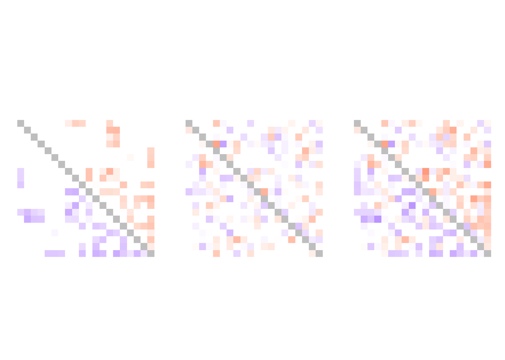

```r
set.seed(1)

J <- BuildWeb(mux = -1 , muy = 1,
              sigmax = 0.5, sigmay = 0.5, size=20,
              rhoxy = -0.8, connectance =0.2)
C <-  AddTIMsToMatrix(J,'Random',TIM_Dens = 5, TIMStrength = 0.5)

ExampleB <- PlotMatrix(J, '')
ExampleA<-PlotMatrix(C, '')
ExampleC<-PlotMatrix(C-J, '')

Combined <- plot_grid(ExampleB, ExampleC, ExampleA,  ncol=3)

labels = c('A\nFull Interaction Matrix',
           'B\n Trophic Interactions',
           'C\nNon-Trophic Interactions')
Combined
```

```r
#ggsave('Figures/ExampleMatrices.png', width = 10,height = 4, dpi =200 )
```

## Figure 3: Example TIM matrices by different distributions.

`PlotTIMMatrices()` can access the different TIM models and return coloured matrix

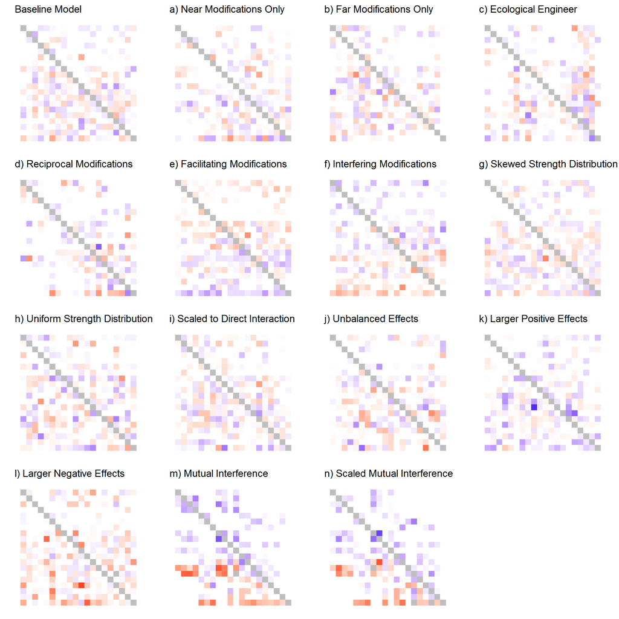

```r
ModelList <- c( 'Normal','Nearby', 'Far','EcoEng','TightRecip',
                'Positive', 'Negative','Unif','LaPlace', 'Scaled',
                'RanSkew', 'IncSkew','DecSkew',
                'Switching','BoundSw' )

matLABELS<- c('Baseline Model',
              'Near Modifications Only',
              'Far Modifications Only',
              'Ecological Engineer',
              'Reciprocal Modifications',
              'Facilitating Modifications',
              'Interfering Modifications',
              'Skewed Strength Distribution',
              'Uniform Strength Distribution',
              'Scaled to Direct Interaction',
              'Unbalanced Effects',
              'Larger Positive Effects',
              'Larger Negative Effects',
              'Mutual Interference',
              'Scaled Mutual Interference')

Lettered_Labels <- paste0(c('',  paste0(letters[1:14],') ') ),matLABELS)

plot_grid(plotlist = map2(ModelList,Lettered_Labels, PlotTIMMatrices, J, 8, 0.5 ), ncol = 4, label_size = 6 )
```

```r
ggsave('Paper/Figures/SuppInfo/AllTIMMatrices.png', width = 12,height = 14 )
ggsave('Paper/Figures/SuppInfo/AllTIMMatrices.pdf', width = 12,height = 14 )
```

## Figure 4: Impact of TIMs on Stability in Artificial Webs

```r
dataB05-> data2
write.csv(data2, file = 'Generated Data/ArtificialWebData.csv')

data2 %>%
  mutate(Highlight = ifelse(TIM_Model %in% Interesting,
                            'Yes',
                            'No'))->data2

glimpse(data2, width = 80)
```

```
## Observations: 14,400
## Variables: 34
## $ obs                  <dbl> 0.7870476, 0.5488945, 0.5126129, 0.5240617, 0....
## $ May                  <dbl> 4.073934, 3.817678, 4.136724, 3.929259, 3.9063...
## $ Tang                 <dbl> 0.2936143, 0.3167496, 0.3581559, 0.3790442, 0....
## $ rho                  <dbl> -0.9278903, -0.9173650, -0.9138707, -0.9040044...
## $ mu                   <dbl> 0.0001681629, -0.0013908279, -0.0020381616, -0...
## $ Omega                <dbl> 0.073436773, 0.056114655, 0.142749704, 0.03134...
## $ Omega_d2             <dbl> 0.2548756, 0.2499255, 0.2327542, 0.2016597, 0....
## $ Omega_d5             <dbl> 0.3499040, 0.3662037, 0.3398690, 0.3240116, 0....
## $ DotToRightOfDiskMay  <lgl> FALSE, FALSE, FALSE, FALSE, FALSE, FALSE, FALS...
## $ DotToRightOfDiskTang <lgl> FALSE, FALSE, FALSE, FALSE, FALSE, FALSE, FALS...
## $ V                    <dbl> 0.2813272, 0.2468483, 0.2897564, 0.2614064, 0....
## $ cov                  <dbl> 6.066989e-04, -9.009090e-04, 3.408509e-04, -1....
## $ NT_VAR               <dbl> 0.2981527, 0.3532751, 0.4715158, 0.4784152, 0....
```

[output cut: 21 more lines]

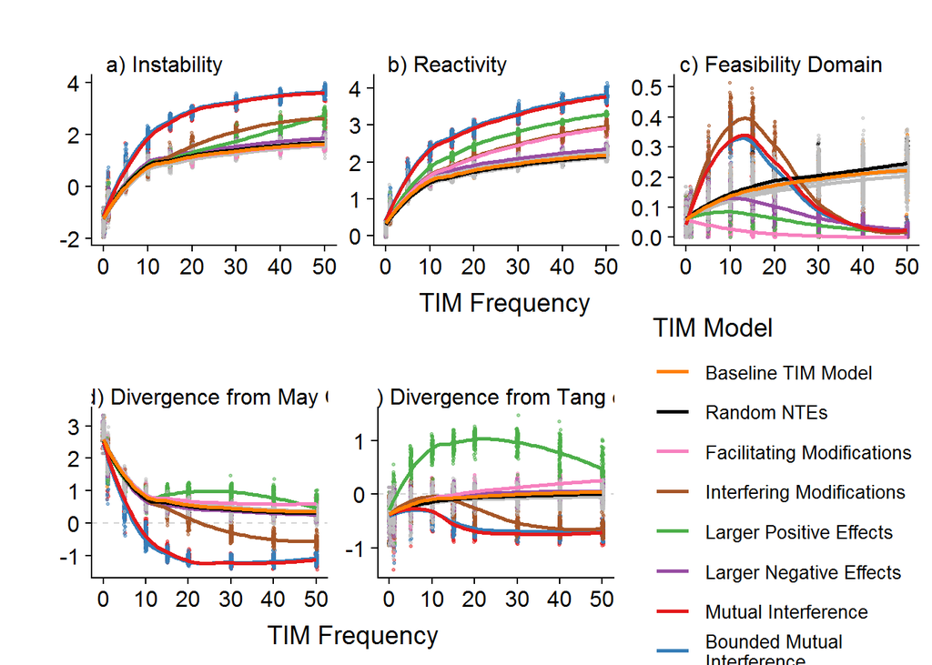

```r
data2 %>%
  mutate(Instability = log(obs),
         Reactivity=log(Reactivity)) %>%
  gather('Response', 'Value',
         Instability,
         Omega,
         Reactivity)%>%
  mutate(Response = factor(Response,
                           levels= c('Instability',
                                     'Reactivity',
                                     'Omega'),
                           labels = Labels <- c('a) Instability',
                                                'b) Reactivity',
                                                'c) Feasibility Domain')))-> df

ggplot(df, aes(y=Value, x=TIM_Dens, col=TIM_Model))+
  geom_jitter(size=0.5 , width = 0.2, height = 0, alpha = 0.5 )+
  geom_smooth(data= subset(df,Highlight=='No'), se = FALSE, alpha=0.5)+
  geom_smooth(data= subset(df,Highlight=='Yes'), se = FALSE, alpha=0.5)+
  geom_smooth(data= subset(df,TIM_Model=='Normal'), se = FALSE, alpha=0.5)+
  facet_wrap(~Response, scales = 'free' )+
  guides(col=FALSE)+
  theme(strip.background = element_blank(),
        strip.text = element_text(hjust = 0.1, margin = margin(1,1,1,1)))+
  labs(title="",
       y='',
       x='TIM Frequency')+InterestingColours -> TopRow


data2 %>%
  mutate(Stability = log(obs),
         `Divergence from Tang Criterion` = log(Tang)-Stability,
         `Divergence from May Criterion` = log(May)-Stability) %>%
  gather('Response', 'Value',
         `Divergence from Tang Criterion`,
         `Divergence from May Criterion`)%>%
  mutate(Response = factor(Response,
                           levels= c('Divergence from May Criterion',
                                     'Divergence from Tang Criterion' ),
                           labels = c('d) Divergence from May Criterion',
                                      'e) Divergence from Tang et al. Criterion' )))-> df

ggplot(df, aes(y=Value, x=TIM_Dens, col=TIM_Model))+
  geom_hline(yintercept = 0, linetype=2, col= 'lightgrey') +
  geom_jitter(size=0.5 , width = 0.2, height = 0, alpha = 0.5 )+
  geom_smooth(data= subset(df,Highlight=='No'), se = FALSE, alpha=0.5)+
  geom_smooth(data= subset(df,Highlight=='Yes'), se = FALSE, alpha=0.5)+
  geom_smooth(data= subset(df,TIM_Model=='Normal'), se = FALSE, alpha=0.5)+
  facet_wrap(~Response, scales = 'free')+
  theme(strip.background = element_rect(fill = 'white'),
        strip.text = element_text(hjust = 0.1, margin = margin(1,1,1,1)))+
  labs(title="",
       y='',
       x='TIM Frequency')+InterestingColours+
  LEGEND-> BottomRow

Both<-cowplot::plot_grid(TopRow, BottomRow, nrow = 2)

Both
```

```r
ggsave('Paper/Figures/MainText/Figure4.pdf', width = 12, height = 9)
ggsave('Paper/Figures/MainText/Figure4.png', width = 12, height = 9, dpi=300)
```

## Sensitivity analysis with varying TIM strength and balance of trophic strengths

NB bound switching doesn’t respond to changing TIM strength, so is removed

### Stability

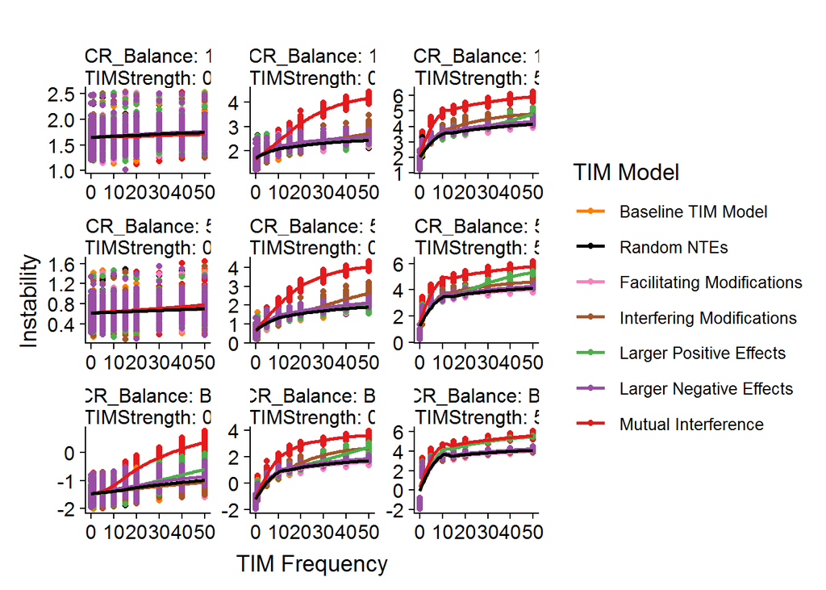

```r
bind_rows(mutate(dataBal, CR_Balance = 'Balanced'),
          mutate(dataUn, CR_Balance = '5x'),
          mutate(dataVeUn, CR_Balance = '10x'))%>%
  filter(TIM_Model != 'BoundSw')%>%
  filter(TIM_Model %in% Interesting) %>%
  mutate(Instability = log(obs))%>%
  ggplot(aes(y = Instability, x = TIM_Dens, col= TIM_Model))+
  geom_point()+
  geom_smooth(se=FALSE)+
  theme(strip.background = element_rect(fill = 'white'),
        strip.text = element_text(hjust = 0.1, margin = margin(1,1,1,1)))+
  labs(title="",
       y='Instability',
       x='TIM Frequency')+
  facet_wrap(CR_Balance~TIMStrength,scales = 'free',
             labeller = label_both)+
  InterestingColours+LEGEND
```

```r
ggsave('Paper/Figures/SuppInfo/Sens_Stability.pdf', width = 12, height = 9)
ggsave('Paper/Figures/SuppInfo/Sens_Stability.png', width = 12, height = 9, dpi=300)
```

### Reactivity

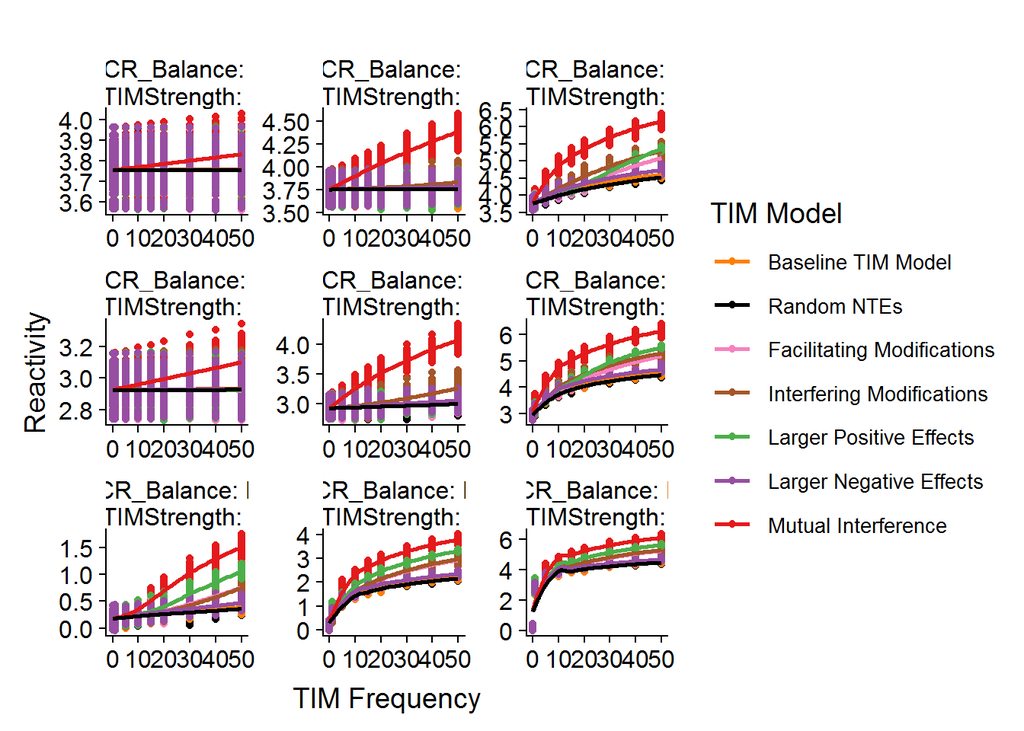

```r
bind_rows(mutate(dataBal, CR_Balance = 'Balanced'),
          mutate(dataUn, CR_Balance = '5x'),
          mutate(dataVeUn, CR_Balance = '10x'))%>%
  filter(TIM_Model != 'BoundSw')%>%
  filter(TIM_Model %in% Interesting) %>%
  mutate(Reactivity=log(Reactivity)) %>%
  ggplot(aes(y = Reactivity, x = TIM_Dens, col= TIM_Model))+
  geom_point()+
  geom_smooth(se=FALSE)+
  theme(strip.background = element_rect(fill = 'white'),
        strip.text = element_text(hjust = 0.1, margin = margin(1,1,1,1)))+
  labs(title="",
       y='Reactivity',
       x='TIM Frequency')+
  facet_wrap(CR_Balance~TIMStrength,scales = 'free',
             labeller = label_both)+
  InterestingColours+LEGEND
```

```r
ggsave('Paper/Figures/SuppInfo/Sens_Reactivity.pdf', width = 12, height = 7)
ggsave('Paper/Figures/SuppInfo/Sens_Reactivity.png', width = 12, height = 7, dpi=300)
```

### Feasibility domain

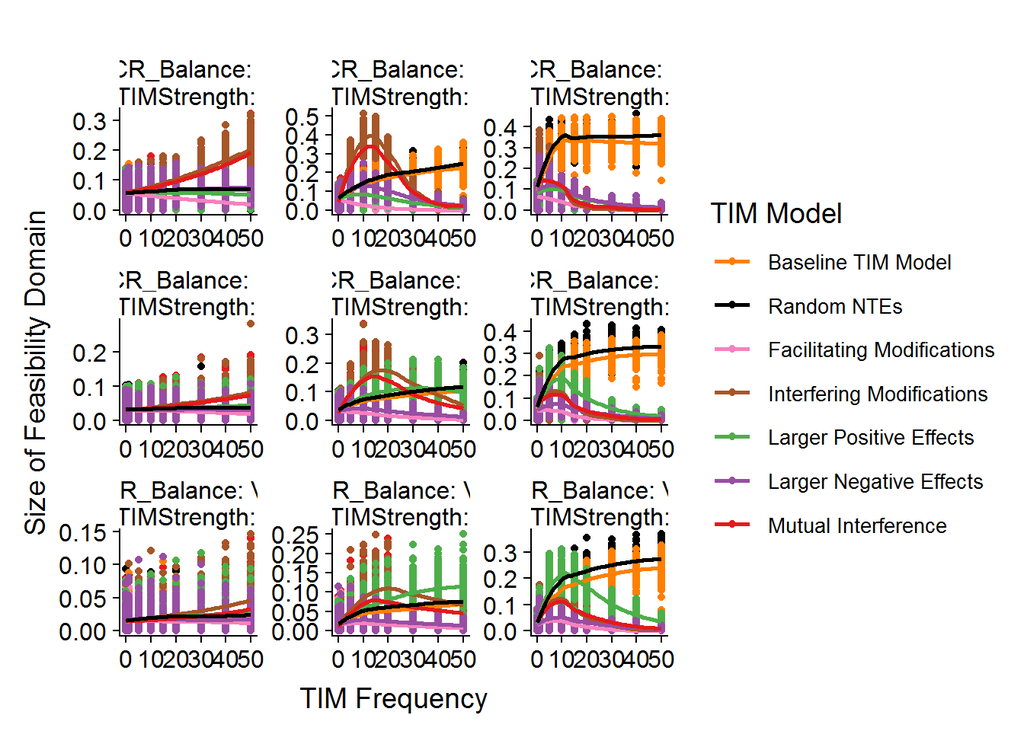

```r
bind_rows(mutate(dataBal, CR_Balance = 'Balanced'),
          mutate(dataUn, CR_Balance = 'Unbalanced'),
          mutate(dataVeUn, CR_Balance = 'VeryUnBalanced'))%>%
  filter(TIM_Model != 'BoundSw')%>%
  filter(TIM_Model %in% Interesting) %>%
  ggplot(aes(y = Omega, x = TIM_Dens, col= TIM_Model))+
  geom_point()+
  geom_smooth(se=FALSE)+
  theme(strip.background = element_rect(fill = 'white'),
        strip.text = element_text(hjust = 0.1, margin = margin(1,1,1,1)))+
  labs(title="",
       y='Size of Feasibility Domain',
       x='TIM Frequency')+
  facet_wrap(CR_Balance~TIMStrength,scales = 'free',
             labeller = label_both)+
  InterestingColours+LEGEND
```

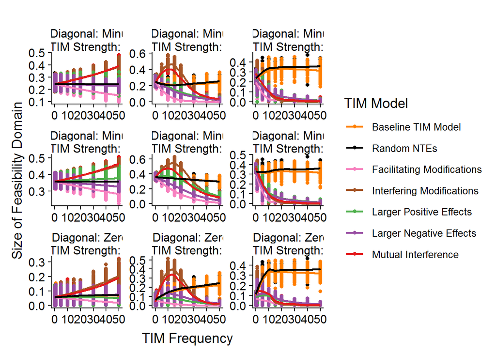

```r
ggsave('Paper/Figures/SuppInfo/Sens_Feasibility.pdf', width = 12, height = 9)
ggsave('Paper/Figures/SuppInfo/Sens_Feasibility.png', width = 12, height = 9, dpi=300)
dataBal %>%
  filter(TIM_Model != 'BoundSw')%>%
  filter(TIM_Model %in% Interesting) %>%
  rename(Zero =Omega, `Minus 2` = Omega_d2, `Minus 5`=Omega_d5,
         `TIM Strength` = TIMStrength)%>%
  gather('Diagonal', 'FeasibilityDomain',
         Zero, `Minus 2`, `Minus 5`)%>%
  ggplot(aes(y = FeasibilityDomain, x = TIM_Dens, col= TIM_Model))+
  geom_point()+
  geom_smooth(se=FALSE)+
  theme(strip.background = element_rect(fill = 'white'),
        strip.text = element_text(hjust = 0.1, margin = margin(1,1,1,1)))+
  facet_wrap(Diagonal~`TIM Strength`,scales = 'free',
             labeller = label_both)+
  labs(title="",
       y='Size of Feasibility Domain',
       x='TIM Frequency')+
  InterestingColours+LEGEND
```

```r
ggsave('Paper/Figures/SuppInfo/Sens_Diagonal.pdf', width = 12, height = 9)
ggsave('Paper/Figures/SuppInfo/Sens_Diagonal.png', width = 12, height = 9, dpi=300)
```